# Saglik Sigortasi Analizi

# Yorum

Bu modelin de MSE oranı düşük olduğundan başarılı diyebiliriz ama karşılaştırdığımızda ilk modelin daha başarılı olduğunu görüyoruz.

## (b)

Uygun ayarlanma parametrelerini seçerek Bagging ve Random Forest algoritmalarını eğitiniz. Her bir algoritmanın test MSE değerlerini hesaplayınız. Öncek sonuçlarla birlikte tartışınız. Bu yöntemlere göre önemli değişkenler hangileridir?

```r
library(randomForest)
# Bagging modeli oluşturma
set.seed(123)
bagging_model <- randomForest(lmaliyet ~ yas + cinsiyet + BMI + cocuksay + sigara + bolge, data = train_data, mtry = ncol(train_data) - 1, importance = TRUE)
# Tahmin yapma
bagging_predictions <- predict(bagging_model, newdata = test_data)

# Bagging modeli için MSE hesaplama
bagging_mse <- mean((test_data$lmaliyet - bagging_predictions)^2)
print(paste("Bagging Modeli Test MSE:", bagging_mse))
```

```
## [1] "Bagging Modeli Test MSE: 0.143720023201608"
```

```r
# Random Forest modeli oluşturma
set.seed(123)
rf_model <- randomForest(lmaliyet ~ yas + cinsiyet + BMI + cocuksay + sigara + bolge, data = train_data, importance = TRUE)

# Tahmin yapma
rf_predictions <- predict(rf_model, newdata = test_data)

# Random Forest modeli için MSE hesaplama
rf_mse <- mean((test_data$lmaliyet - rf_predictions)^2)
print(paste("Random Forest Modeli Test MSE:", rf_mse))
```

```
## [1] "Random Forest Modeli Test MSE: 0.142651620050868"
```

```r
# Değişken önemini belirleme
importance(bagging_model)
```

```
##             %IncMSE IncNodePurity
## yas      161.207862    229.703329
## cinsiyet   1.971613      4.587227
## BMI       26.987706     45.987784
## cocuksay  37.734986     30.016521
## sigara   174.056989    287.552669
## bolge     10.981386     13.301930
```

```r
importance(rf_model)
```

```
##             %IncMSE IncNodePurity
## yas       90.227772    193.538933
## cinsiyet   1.016163      6.483922
## BMI       18.230357     51.171256
## cocuksay  27.654254     27.351919
## sigara   137.841614    272.446987
## bolge      5.375678     14.863851
```

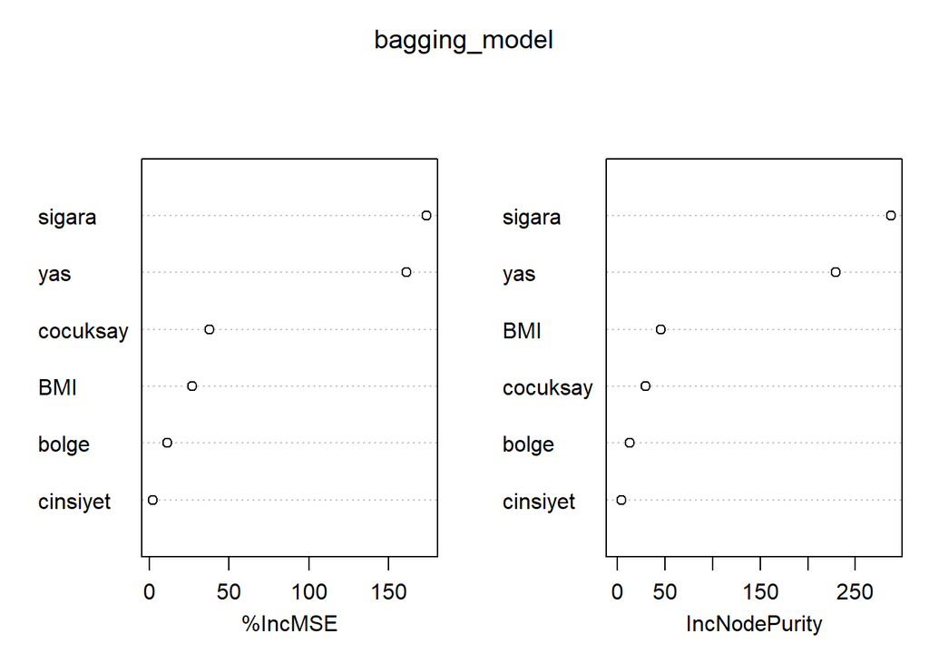

```r
# Değişken önemini grafiksel olarak gösterme
varImpPlot(bagging_model)
```

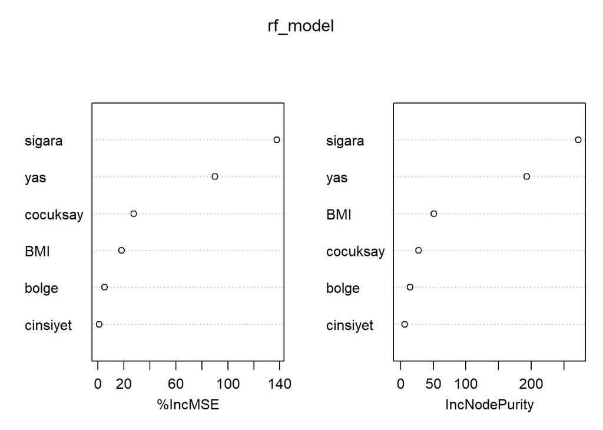

```r
varImpPlot(rf_model)
```

# Yorum

Random Forest modeli, en düşük Test MSE değerine sahip olduğu için en iyi performansı gösteren modeldir.

Sigara kullanımı, yaş, BMI ve çocuk sayısı en önemli değişkenlerdir. Sigara kullanımı en yüksek etkiye sahip değişkendir.

# Soru 3

## (a)

Önceki sorulardaki sigorta veri kümesini kullanarak lmaliyet için Boosting algoritmasını eğitmek istiyoruz. Uygun ayarlanma parametrelerini kullanarak GBM paketi ile modeli eğitiniz. Test MSE değerini hesaplayınız ve önceki sonuçlarla karşılaştırınız.

```r
library(gbm)
# Boosting modeli oluşturma
set.seed(1)
boost_model <- gbm(lmaliyet ~ yas + cinsiyet + BMI + cocuksay + sigara + bolge,
                   data = train_data,
                   distribution = "gaussian",
                   n.trees = 1000,
                   interaction.depth = 1,
                   shrinkage = 0.2)

# Tahmin yapma
boost_predictions <- predict(boost_model, newdata = test_data, n.trees = 1000)

# MSE hesaplama
boost_mse <- mean((test_data$lmaliyet - boost_predictions)^2)
print(paste("Boosting Modeli Test MSE:", boost_mse))
```

```
## [1] "Boosting Modeli Test MSE: 0.192925672145215"
```

# Yorum

Diğer modellere göre hata oranı yüksek olduğundan başarısızdır.

## (b)

GBM boosting algoritmasında seçmemiz gereken 3 ayarlanma parametresi vardır. Bu hiperparametreler için aşağıdaki gibi bir grid oluşturalım.

```r
# Hiperparametre gridini oluşturma
B <- c(500, 1000, 2000, 5000) # n.trees
d <- c(1, 2, 3, 4)            # interaction.depth
lambda <- c(0.001, 0.01, 0.02, 0.03, 0.05, 0.1, 0.2) # shrinkage
G <- expand.grid(B = B, d = d, lambda = lambda)
```

Eğitim verilerini kullanarak 5-katlı çapraz geçerleme yöntemi ile optimal ayarlanma parametrelerini seçiniz. Bu değerleri kullanarak test MSE’yi hesaplayınız.

```r
# Eğitim ve test MSE değerlerini saklamak için
nG <- nrow(G)
boost_train_MSE <- rep(NA, nG)
boost_test_MSE <- rep(NA, nG)
cv_errors <- rep(NA, nG)

# Boosting modeli eğitme ve çapraz doğrulama ile MSE hesaplama
set.seed(1)
for (i in 1:nG) {
  params <- G[i, ]
  model <- gbm(lmaliyet ~ yas + cinsiyet + BMI + cocuksay + sigara + bolge,
               data = train_data,
               distribution = "gaussian",
               n.trees = params$B,
               interaction.depth = params$d,
               shrinkage = params$lambda,
               cv.folds = 5)

  # Çapraz doğrulama hatası
  cv_errors[i] <- min(model$cv.error)

  # Test seti MSE
  boost_pred_test <- predict(model, newdata = test_data, n.trees = params$B)
  boost_test_MSE[i] <- mean((test_data$lmaliyet - boost_pred_test)^2)

  # Eğitim seti MSE
  boost_pred_train <- predict(model, newdata = train_data, n.trees = params$B)
  boost_train_MSE[i] <- mean((train_data$lmaliyet - boost_pred_train)^2)
}

# En iyi parametreleri bulma
best_params <- G[which.min(cv_errors), ]
best_test_MSE <- min(boost_test_MSE)
print(paste("En iyi parametreler: n.trees =", best_params$B,
            "interaction.depth =", best_params$d,
            "shrinkage =", best_params$lambda))
```

```
## [1] "En iyi parametreler: n.trees = 2000 interaction.depth = 4 shrinkage = 0.05"
```

```r
print(paste("Boosting Modeli En İyi Test MSE:", best_test_MSE))
```

```
## [1] "Boosting Modeli En İyi Test MSE: 0.127327713784382"
```

# Soru 4

Bu soruda döviz kurunun yönünü (yukarı/aşağı) sınıflandırmaya çalışacağız. USD/TL döviz kurundaki günlük değişimin yönünü (up/down) son 5 günlük döviz kuru ve hisse senedi piyasası değişimlerinden hareketle öngörmek istiyoruz.

`finmarkets.RData` 13/01/2000 - 04/05/2020 dönemini kapsayan 5086 günlük gözlemden oluşmaktadır.

```r
library(tidyverse)
load("finmarkets.RData")
str(finmarkets)
```

```
## 'data.frame':    5086 obs. of  20 variables:
##  $ datechar     : chr  "2000-01-13" "2000-01-14" "2000-01-17" "2000-01-18" ...
##  $ year         : chr  "2000" "2000" "2000" "2000" ...
##  $ month        : chr  "01" "01" "01" "01" ...
##  $ day          : Ord.factor w/ 7 levels "Pazar"<"Pazartesi"<..: 5 6 2 3 4 6 2 3 4 5 ...
##  $ bist100      : num  18138 19110 18458 19577 19288 ...
##  $ usd          : num  0.539 0.54 0.543 0.546 0.546 ...
##  $ bistret      : num  6.87 5.22 -3.47 5.89 -1.49 ...
##  $ bistdirection: Factor w/ 2 levels "Down","Up": 2 2 1 2 1 1 1 2 2 2 ...
##  $ bistretlag1  : num  3.53 6.87 5.22 -3.47 5.89 ...
##  $ bistretlag2  : num  3.17 3.53 6.87 5.22 -3.47 ...
##  $ bistretlag3  : num  -2.27 3.17 3.53 6.87 5.22 ...
##  $ bistretlag4  : num  -4.42 -2.27 3.17 3.53 6.87 ...
##  $ bistretlag5  : num  -3.37 -4.42 -2.27 3.17 3.53 ...
##  $ usdret       : num  -0.0619 0.196 0.4419 0.6445 0.0304 ...
##  $ usddirection : Factor w/ 2 levels "Down","Up": 1 2 2 2 2 2 2 2 2 2 ...
##  $ usdretlag1   : num  0.8285 -0.0619 0.196 0.4419 0.6445 ...
##  $ usdretlag2   : num  0 0.8285 -0.0619 0.196 0.4419 ...
##  $ usdretlag3   : num  0.00299 0 0.82846 -0.06192 0.196 ...
##  $ usdretlag4   : num  -0.12587 0.00299 0 0.82846 -0.06192 ...
##  $ usdretlag5   : num  -0.92476 -0.12587 0.00299 0 0.82846 ...
##  - attr(*, "na.action")= 'omit' Named int [1:6] 1 2 3 4 5 6
##   ..- attr(*, "names")= chr [1:6] "1" "2" "3" "4" ...
```

`usdret`: USD/TL döviz kurundaki günlük değişim, %.

`usddirection`: iki seviyeli faktör değişkeni, usdret’in işaret negatifse “Down”, pozitifse “Up”.

`usdretlag1-usdretlag5`: usdret’in 5 günlük gecikmeli değerleri, birinci gecikme, ikinci gecikme, vs.

`bistretlag1-bistretlag5`: BIST100 getirilerinin gecikmeli değerleri.

Bugünkü döviz kurunun yönünü öngörmek isteyen bir yatırımcının son beş günlük döviz kuru ve BIST100 hareketlerini bildiğini varsayıyoruz.

Verileri aşağıdaki gibi eğitim ve test kümelerine ayıralım:

```r
fin_train <- finmarkets |> filter(year<=2016)
fin_test <- finmarkets |> filter(year>2016)
```

## (a)

Eğitim kümesini kullanarak hedef değişken `usddirection` için bir lojistik regresyon sınıflandırma modeli eğitiniz. Modelde sadece `usdretlag1` - `usdretlag5` gecikme değişkenlerini (5 değişken) kullanın. Test verilerini kullanarak doğruluk ve hata oranlarını hesaplayınız. Karışıklık matrisini (Confusion matrix) hesaplayınız ve yorumlayınız. No information rate kaçtır? Model sizce başarılı mı?

```r
library(caret)
# Lojistik regresyon modeli oluşturma
logistic_model <- glm(usddirection ~ usdretlag1 + usdretlag2 + usdretlag3 + usdretlag4 + usdretlag5,
                      data = fin_train,
                      family = binomial)

summary(logistic_model)
```

```
##
## Call:
## glm(formula = usddirection ~ usdretlag1 + usdretlag2 + usdretlag3 +
##     usdretlag4 + usdretlag5, family = binomial, data = fin_train)
##
## Coefficients:
##              Estimate Std. Error z value Pr(>|z|)
## (Intercept) -0.033688   0.030854  -1.092  0.27489
## usdretlag1   0.100343   0.033201   3.022  0.00251 **
## usdretlag2  -0.088136   0.031548  -2.794  0.00521 **
## usdretlag3   0.009199   0.031371   0.293  0.76934
## usdretlag4   0.014897   0.029842   0.499  0.61765
## usdretlag5  -0.007843   0.028918  -0.271  0.78624
## ---
## Signif. codes:  0 '***' 0.001 '**' 0.01 '*' 0.05 '.' 0.1 ' ' 1
##
## (Dispersion parameter for binomial family taken to be 1)
##
##     Null deviance: 5894.8  on 4252  degrees of freedom
## Residual deviance: 5877.1  on 4247  degrees of freedom
## AIC: 5889.1
##
## Number of Fisher Scoring iterations: 3
```

```r
# Tahmin
test_pred_prob <- predict(logistic_model, newdata = fin_test, type = "response")
test_pred <- ifelse(test_pred_prob > 0.5, "Up", "Down")

# Doğruluk ve hata oranlarını hesaplama
confusion_matrix <- confusionMatrix(factor(test_pred, levels = c("Down", "Up")), fin_test$usddirection)
accuracy <- confusion_matrix$overall['Accuracy']
error_rate <- 1 - accuracy
print(paste("Doğruluk:", accuracy))
```

```
## [1] "Doğruluk: 0.535414165666267"
```

```r
print(paste("Hata Oranı:", error_rate))
```

```
## [1] "Hata Oranı: 0.464585834333733"
```

```r
print(confusion_matrix)
```

```
## Confusion Matrix and Statistics
##
##           Reference
## Prediction Down  Up
##       Down  270 264
##       Up    123 176
##
##                Accuracy : 0.5354
##                  95% CI : (0.5009, 0.5697)
##     No Information Rate : 0.5282
##     P-Value [Acc > NIR] : 0.3515
##
##                   Kappa : 0.0854
##
##  Mcnemar's Test P-Value : 1.106e-12
##
##             Sensitivity : 0.6870
##             Specificity : 0.4000
##          Pos Pred Value : 0.5056
##          Neg Pred Value : 0.5886
##              Prevalence : 0.4718
##          Detection Rate : 0.3241
##    Detection Prevalence : 0.6411
##       Balanced Accuracy : 0.5435
##
##        'Positive' Class : Down
##
```

```r
# No Information Rate hesaplama
nir <- max(table(fin_test$usddirection)) / nrow(fin_test)
print(paste("No Information Rate (NIR):", nir))
```

```
## [1] "No Information Rate (NIR): 0.528211284513806"
```

# Yorum

## (b)

Lojistik regresyon modelini `usdretlag1` - `usdretlag5` gecikmelerinin yanı sıra BIST100 gecikmelerini, `bistretlag1`-`bistretlag5`, ekleyerek genişletiniz (toplamda 10 değişkenli bir model) ve eğitiniz. Modelin performansını test verilerinden hareketle değerlendiriniz ve öncek kısımdaki sonuçlarla karşılaştırınız. Test performansına göre hangi model daha başarılıdır? Seçtiğiniz modeli yatırım stratejilerinizde kullanır mısınız? Tartışınız.

```r
# Genişletilmiş lojistik regresyon modeli oluşturma
logistic_model_extended <- glm(usddirection ~ usdretlag1 + usdretlag2 + usdretlag3 + usdretlag4 + usdretlag5 +
                                 bistretlag1 + bistretlag2 + bistretlag3 + bistretlag4 + bistretlag5,
                               data = fin_train,
                               family = binomial)

summary(logistic_model_extended)
```

```
##
## Call:
## glm(formula = usddirection ~ usdretlag1 + usdretlag2 + usdretlag3 +
##     usdretlag4 + usdretlag5 + bistretlag1 + bistretlag2 + bistretlag3 +
##     bistretlag4 + bistretlag5, family = binomial, data = fin_train)
##
## Coefficients:
##              Estimate Std. Error z value Pr(>|z|)
## (Intercept) -0.014355   0.032459  -0.442   0.6583
## usdretlag1   0.004171   0.039230   0.106   0.9153
## usdretlag2  -0.082751   0.039796  -2.079   0.0376 *
## usdretlag3   0.008788   0.034903   0.252   0.8012
## usdretlag4   0.017071   0.034239   0.499   0.6181
## usdretlag5   0.027243   0.031539   0.864   0.3877
## bistretlag1 -0.290354   0.018121 -16.023   <2e-16 ***
## bistretlag2 -0.169397   0.017352  -9.762   <2e-16 ***
## bistretlag3 -0.018233   0.017319  -1.053   0.2924
## bistretlag4  0.006933   0.016664   0.416   0.6774
## bistretlag5  0.011960   0.016705   0.716   0.4740
## ---
## Signif. codes:  0 '***' 0.001 '**' 0.01 '*' 0.05 '.' 0.1 ' ' 1
##
## (Dispersion parameter for binomial family taken to be 1)
##
##     Null deviance: 5894.8  on 4252  degrees of freedom
## Residual deviance: 5470.9  on 4242  degrees of freedom
## AIC: 5492.9
##
## Number of Fisher Scoring iterations: 4
```

```r
# Test verileri üzerinde tahmin yapma
test_pred_prob_extended <- predict(logistic_model_extended, newdata = fin_test, type = "response")
test_pred_extended <- ifelse(test_pred_prob_extended > 0.5, "Up", "Down")

# Karışıklık matrisini hesaplama
confusion_matrix_extended <- confusionMatrix(factor(test_pred_extended, levels = c("Down", "Up")), fin_test$usddirection)

# Doğruluk oranı (accuracy) ve hata oranını (error rate) hesaplama
accuracy_extended <- confusion_matrix_extended$overall['Accuracy']
error_rate_extended <- 1 - as.numeric(accuracy_extended)
print(paste("Doğruluk:", as.numeric(accuracy_extended)))
```

```
## [1] "Doğruluk: 0.611044417767107"
```

```r
print(paste("Hata Oranı:", error_rate_extended))
```

```
## [1] "Hata Oranı: 0.388955582232893"
```

```r
# Karışıklık matrisini yazdırma
print(confusion_matrix_extended)
```

```
## Confusion Matrix and Statistics
##
##           Reference
## Prediction Down  Up
##       Down  267 198
##       Up    126 242
##
##                Accuracy : 0.611
##                  95% CI : (0.577, 0.6443)
##     No Information Rate : 0.5282
##     P-Value [Acc > NIR] : 8.802e-07
##
##                   Kappa : 0.2272
##
##  Mcnemar's Test P-Value : 7.999e-05
##
##             Sensitivity : 0.6794
##             Specificity : 0.5500
##          Pos Pred Value : 0.5742
##          Neg Pred Value : 0.6576
##              Prevalence : 0.4718
##          Detection Rate : 0.3205
##    Detection Prevalence : 0.5582
##       Balanced Accuracy : 0.6147
##
##        'Positive' Class : Down
##
```

```r
# No Information Rate (NIR) hesaplama
nir_extended <- max(table(fin_test$usddirection)) / nrow(fin_test)
print(paste("No Information Rate (NIR):", nir_extended))
```

```
## [1] "No Information Rate (NIR): 0.528211284513806"
```

#Yorum Genişletilmiş modelin doğruluk oranı (%61.1), NIR’den (%52.82) anlamlı derecede yüksektir. Bu modelin daha başarılı olduğunu söyleyebiliriz.

Model, döviz kuru yönünü tahmin etmede makul bir başarıya sahiptir ve belirli bir yatırım stratejisi için kullanılabilir. Ancak yine de geliştirilmelidir.

# Soru 5

`yasamveri2015.RData` dosyasında `veriler` isimli bir veri çerçevesi içinde Türkiye’de il düzeyinde mutluluk endeksi ile bazı il özelliklerine ilişkin değişkenler yer almaktadır.

```r
load("yasamveri2015.RData")
str(veriler)
```

```
## tibble [81 x 42] (S3: tbl_df/tbl/data.frame)
##  $ il                 : chr [1:81] "Adana" "Adıyaman" "Afyonkarahisar" "Ağrı" ...
##  $ oda                : num [1:81] 1.22 0.93 1.36 0.84 1.4 1.57 1.38 1.62 1.45 1.55 ...
##  $ tuv                : num [1:81] 86.3 77.1 90.2 64.1 95 ...
##  $ ev_kalite          : num [1:81] 22.7 41.1 12.9 40.5 16.9 ...
##  $ istihdam           : num [1:81] 43.3 39.2 51.1 53.2 47.4 44.5 52.9 47.1 51.4 44.4 ...
##  $ issizlik           : num [1:81] 13.2 9.1 5.6 6.8 6.6 10.2 7.9 7.1 6.9 6 ...
##  $ ort_gun_kazanc     : num [1:81] 59.1 53.2 53.9 56.1 53.8 ...
##  $ is_tatmin          : num [1:81] 73.3 64.3 85.3 64 88.7 ...
##  $ tasarruf           : num [1:81] 5428 1543 4062 842 3121 ...
##  $ orta_ust_gelir_gr  : num [1:81] 34.1 16.3 29.7 22.6 34.8 ...
##  $ temel_iht_gr       : num [1:81] 59.8 74.8 44.1 73.5 43.8 ...
##  $ bebek_mort         : num [1:81] 13.18 12.06 9.57 14.43 15.38 ...
##  $ yasam_bek          : num [1:81] 77.4 79.5 77 75.6 77.8 ...
##  $ doktor_basv        : num [1:81] 5323 7437 5727 6720 8067 ...
```

[output cut: 28 more lines]

## (a)

İllerin mutluluk düzeyinin histogramını çiziniz ve özet istatistikleri ile birlikte yorumlayınız. İlleri mutluluk düzeyine göre büyükten küçüğe doğru sıralayan bir grafik çiziniz. En mutlu ve en mutsuz iller hangileridir?

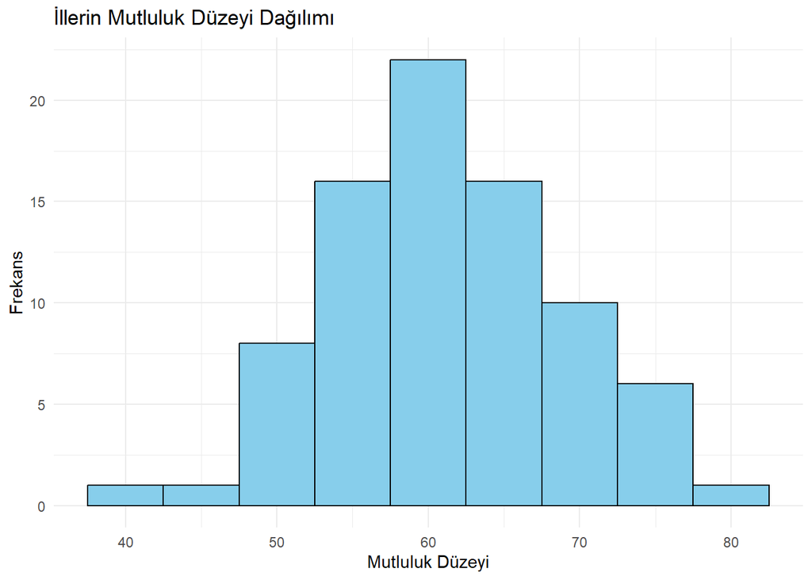

```r
# Mutluluk düzeyinin histogramını çizme
veriler %>%
  ggplot(aes(x = mutluluk)) +
  geom_histogram(binwidth = 5, fill = "skyblue", color = "black") +
  labs(title = "İllerin Mutluluk Düzeyi Dağılımı", x = "Mutluluk Düzeyi", y = "Frekans") +
  theme_minimal()
```

```r
summary(veriler$mutluluk)
```

```
##    Min. 1st Qu.  Median    Mean 3rd Qu.    Max.
##   41.98   56.54   60.39   61.15   65.57   77.66
```

#Yorum Histogramdan, çoğu ilin mutluluk düzeyinin orta aralıkta (55-65) yoğunlaştığını görüyoruz.

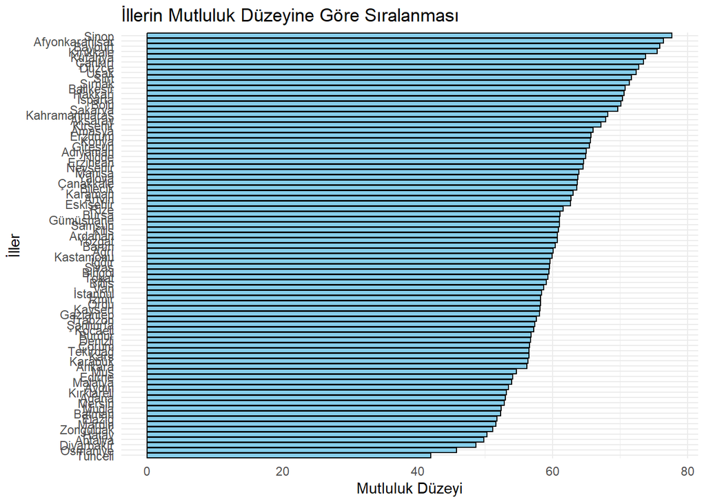

```r
# İlleri mutluluk düzeyine göre sıralama
veriler_sorted <- veriler %>%
  arrange(desc(mutluluk))

# Mutluluk düzeyine göre sıralanmış grafik çizme
veriler_sorted %>%
  ggplot(aes(x = reorder(il, mutluluk), y = mutluluk)) +
  geom_bar(stat = "identity", fill = "skyblue", color = "black") +
  coord_flip() +
  labs(title = "İllerin Mutluluk Düzeyine Göre Sıralanması", x = "İller", y = "Mutluluk Düzeyi") +
  theme_minimal()
```

```r
# En mutlu ve en mutsuz iller
en_mutlu_il <- veriler_sorted[1, "il"]
en_mutlu_mutluluk <- veriler_sorted[1, "mutluluk"]

en_mutsuz_il <- veriler_sorted[nrow(veriler_sorted), "il"]
en_mutsuz_mutluluk <- veriler_sorted[nrow(veriler_sorted), "mutluluk"]

print(paste("En mutlu il:", en_mutlu_il, "Mutluluk düzeyi:", en_mutlu_mutluluk))
```

```
## [1] "En mutlu il: Sinop Mutluluk düzeyi: 77.66"
```

```r
print(paste("En mutsuz il:", en_mutsuz_il, "Mutluluk düzeyi:", en_mutsuz_mutluluk))
```

```
## [1] "En mutsuz il: Tunceli Mutluluk düzeyi: 41.98"
```

## (b)

Hedef değişken `mutluluk` için bir LASSO regresyon modeli tahmin ediniz. Ayarlanma parametresi lambda’ya 5-katlı çapraz geçerleme ile belirleyiniz. Hangi değişkenler seçildi?

```r
library(glmnet)
```

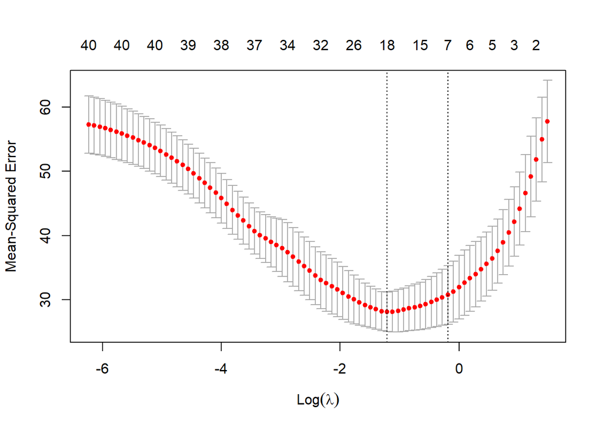

```r
# Hedef değişken (mutluluk)
y <- veriler$mutluluk

# Bağımsız değişkenler
X <- veriler %>%
  select(-mutluluk, -il) %>% # `mutluluk` ve `il` değişkenlerini çıkarıyoruz
  as.matrix()

# LASSO modeli ve 5-katlı çapraz doğrulama
set.seed(123)
cv_lasso <- cv.glmnet(X, y, alpha = 1, nfolds = 5)

# Çapraz doğrulama sonuçlarını görselleştirme
plot(cv_lasso)
```

```r
# En iyi lambda değerini bulma (one standard error rule)
best_lambda <- cv_lasso$lambda.1se
print("LASSO CV en iyi lambda değeri (one standard error):")
```

```
## [1] "LASSO CV en iyi lambda değeri (one standard error):"
```

```r
print(best_lambda)
```

```
## [1] 0.830201
```

```r
# En iyi lambda değeriyle LASSO modelini eğitme
lasso_model <- glmnet(X, y, alpha = 1)

# Seçilen değişkenlerin isimlerini belirleme
lasso_coefficients <- predict(lasso_model, type = "coefficients", s = best_lambda)
lasso_coefficients <- as.matrix(lasso_coefficients) # Matris olarak dönüştür
selected_features <- lasso_coefficients[-1, ] #(intercept)
selected_feature_names <- rownames(lasso_coefficients)[which(selected_features != 0)]

# Seçilen değişkenleri yazdırma
print("Seçilen değişkenler:")
```

```
## [1] "Seçilen değişkenler:"
```

```r
print(selected_feature_names)
```

```
## [1] "ev_kalite"        "doktor_basv"      "atik_hiz"         "gurultu_kir"
## [5] "bel_temiz_tatmin" "tra_kaza"         "avm"
```